# Exploratory Data Analysis - Red Wine Quality

Vikram Iyer

# Familiarize with data

### Objective

To analyze all the chemical properties of the red wine and determine which factors might be resposible for good quality red wine.

### Introduction

Looking at the variables in the dataset, there are some really interesting questions that can be answered.

Let’s explore the data and find out answers to above questions as well as pictographically understand the data. We will be plotting graphs, identifying the outliers and drawing some inferences about data by looking at the various plots(historgrams, scatterplots, bar plots, etc)

# Univariate Analysis

```
##  [1] "fixed.acidity"        "volatile.acidity"     "citric.acid"
##  [4] "residual.sugar"       "chlorides"            "free.sulfur.dioxide"
##  [7] "total.sulfur.dioxide" "density"              "pH"
## [10] "sulphates"            "alcohol"              "quality"
```

```r
# Convert quality to factor
wine$quality.as_factor <- factor(wine$quality)

# Prepare data (quality) for categorization
levels(wine$quality.as_factor)
```

```
## [1] "3" "4" "5" "6" "7" "8"
```

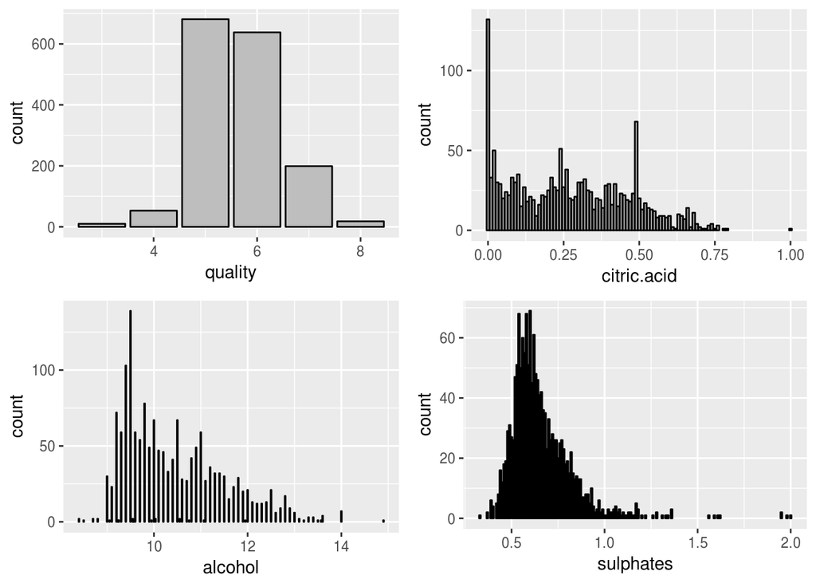

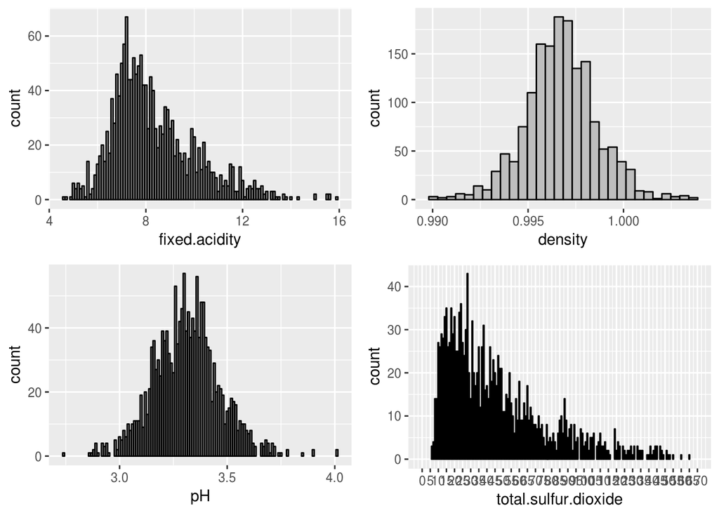

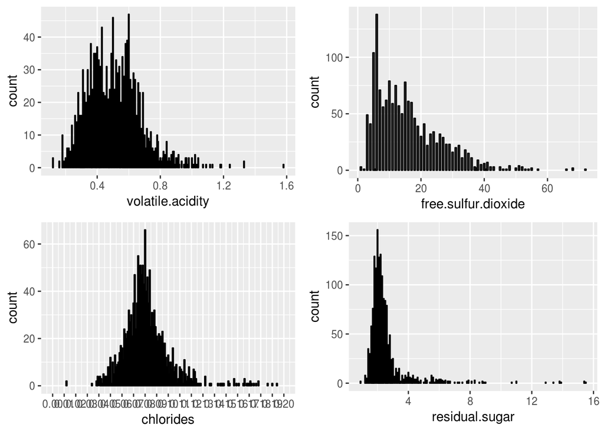

Distributions of the Variables

#### So, we need to transform the variables which do not look normal or close to. We can use the log10

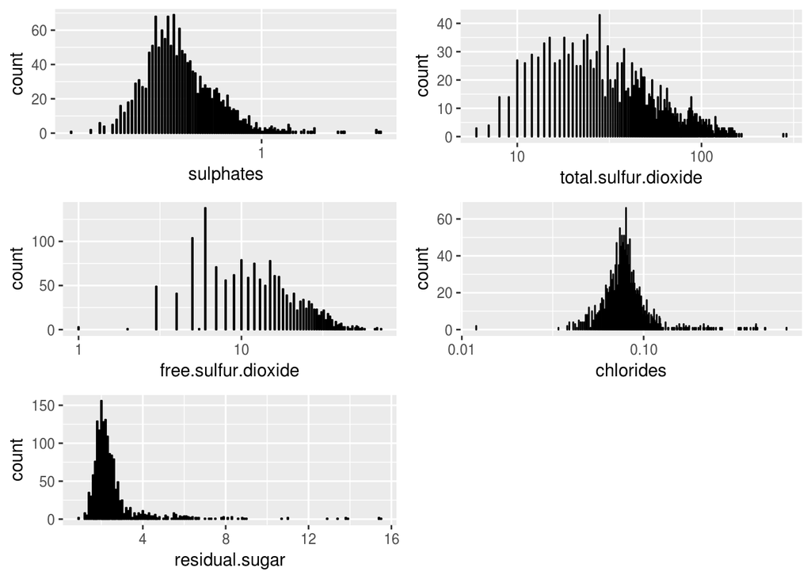

#### Let’s further classify quality of wine into 3 ordinal variables: low(3,4), medium(5,6), best(7,8)

```r
low <- wine$quality <= 4
medium <- wine$quality > 4 & wine$quality < 7
best <- wine$quality > 6
wine$quality.category <- factor(ifelse(low, 'low',
                                ifelse(medium, 'medium', 'best')),
                                levels = c("low", "medium", "best"))
levels(wine$quality.category)
```

```
## [1] "low"    "medium" "best"
```

# BiVariate Analysis

#### Comparing each of the attributes/compounds of wine with quality and coming to conclusions

```
##  [1] "fixed.acidity"        "volatile.acidity"     "citric.acid"
##  [4] "residual.sugar"       "chlorides"            "free.sulfur.dioxide"
##  [7] "total.sulfur.dioxide" "density"              "pH"
## [10] "sulphates"            "alcohol"              "quality"
## [13] "quality.as_factor"    "quality.category"
```

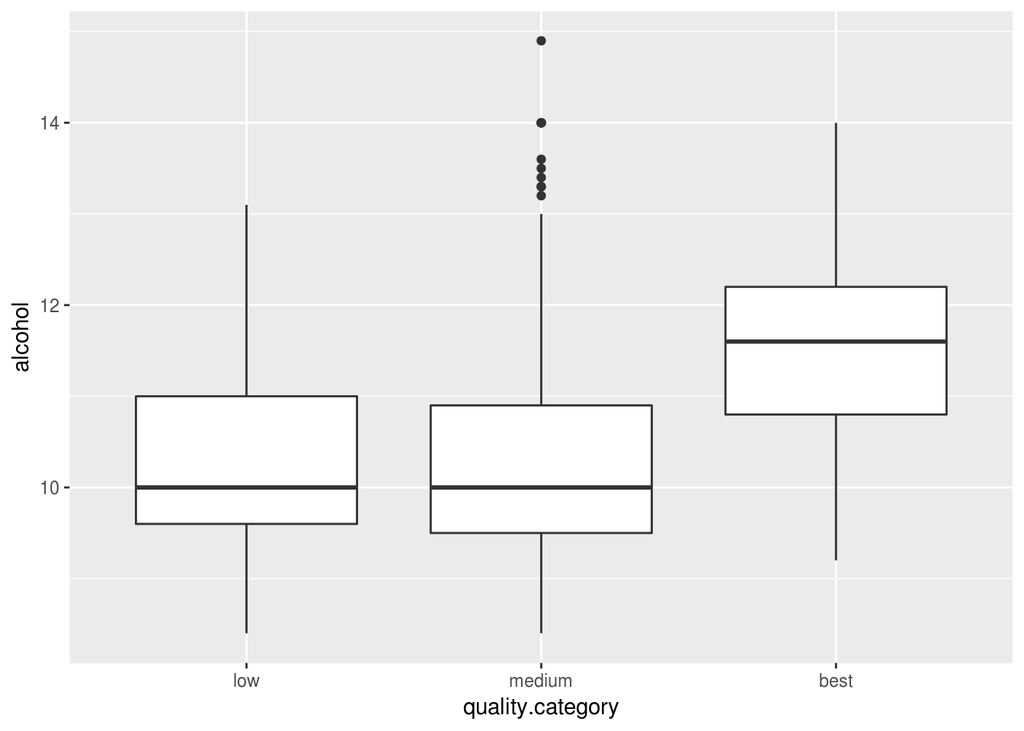

#### Let’s draw plots for all variables against quality of red wine and analyze which variable has a relation(positive, negative, no relation) with quality of red wine

```
##  [1] "fixed.acidity"        "volatile.acidity"     "citric.acid"
##  [4] "residual.sugar"       "chlorides"            "free.sulfur.dioxide"
##  [7] "total.sulfur.dioxide" "density"              "pH"
## [10] "sulphates"            "alcohol"              "quality"
## [13] "quality.as_factor"    "quality.category"
```

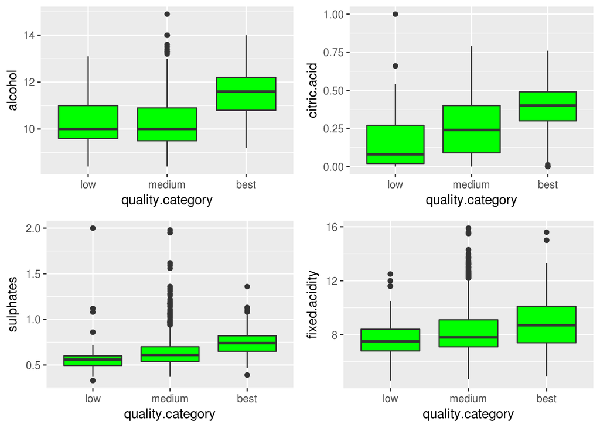

#### Let’s check the remaining ones

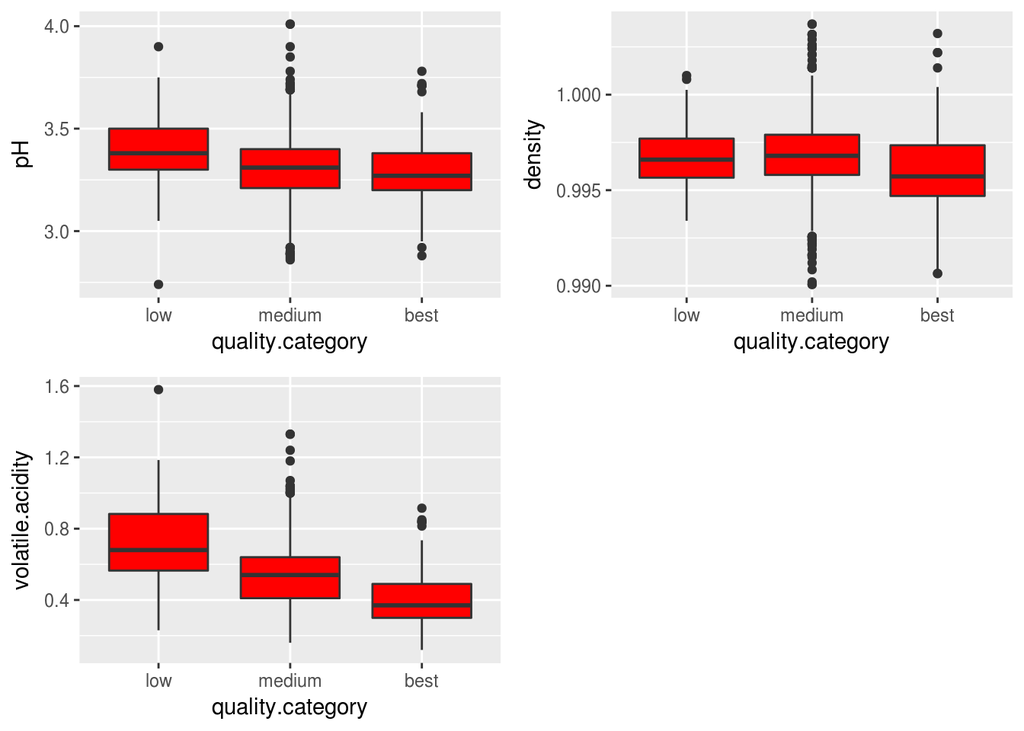

#### *Conclusions*: Some variables which should be checked for corelations are plotted below: (some samples)

# Final plots (Multivariate Analysis)

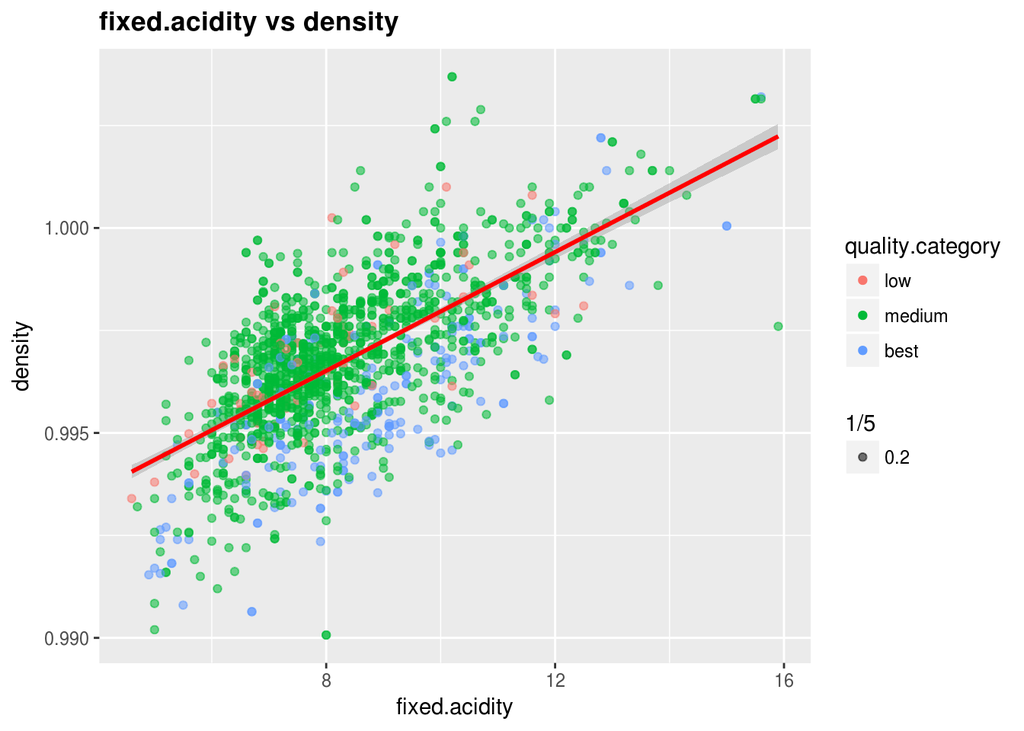

####The above plot clearly shows that, there is a positive corelation between density and fixed.acidity in determining the quality of wine

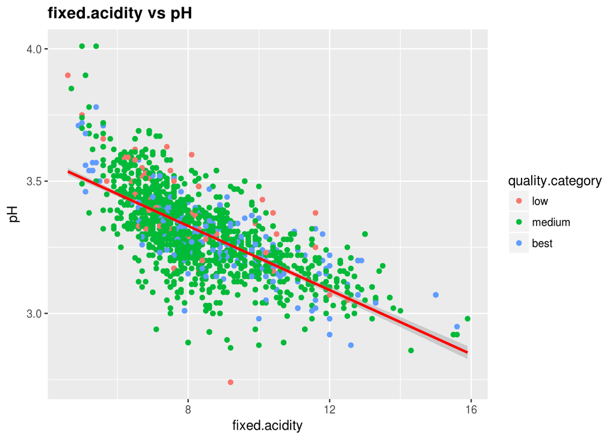

```
## [1] "98 %"
```

#### So, out of the total 1599 observations, approximately 98% observations have pH value in the range 3-4

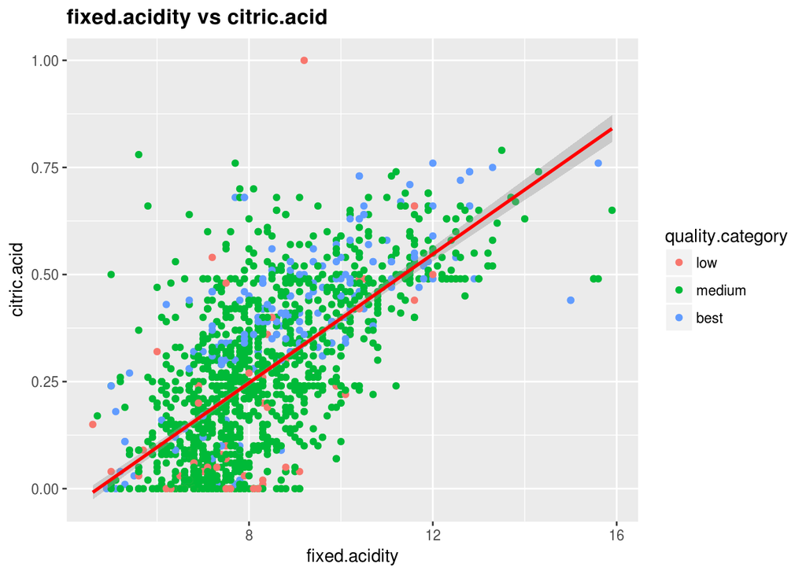

####Let’s just verify if the above plot is uniform across all the levels of quality since I can see a lot of red dots below the corelation slope

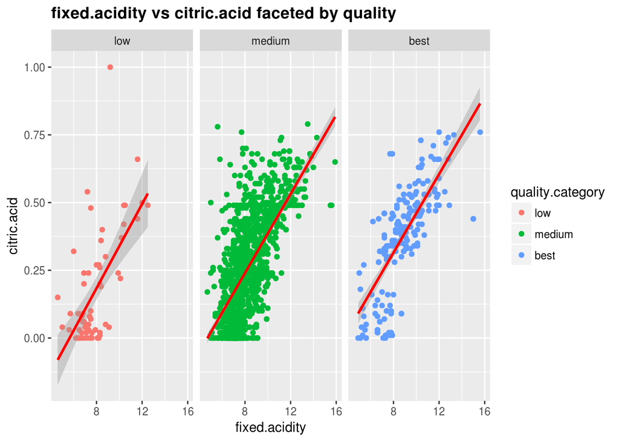

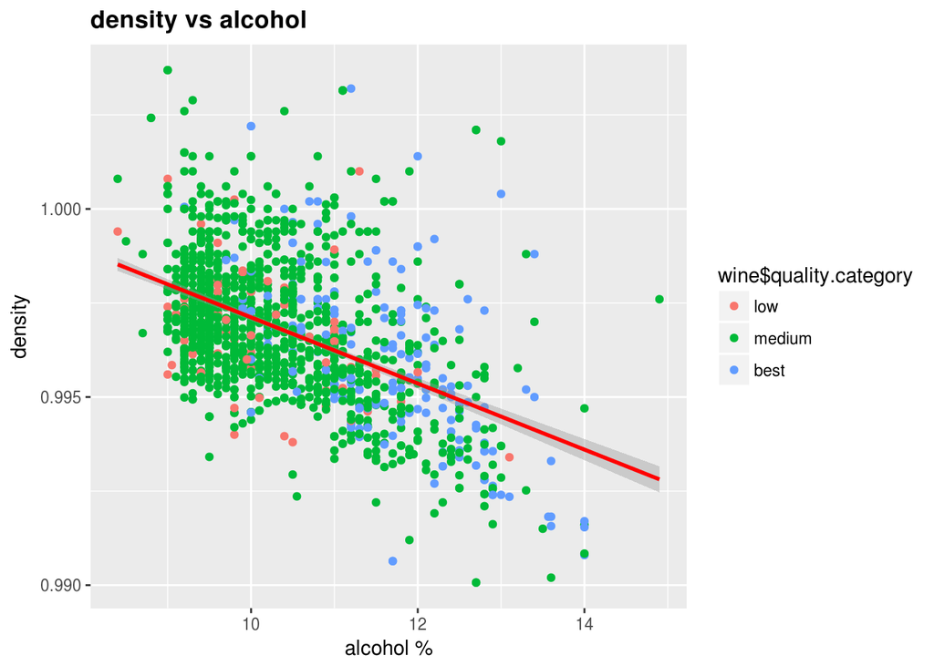

# Reflection

#### While I was plotting the graphs, I had to check each data field with every other one. This dataset was fairly small; however, when dealing with large datasets, not even a single aspect should be missed i.e. considering each and every case and analysis about them. Using the methods done above, there is a lot of manual work. To reduce this manual work, we should be depending more on robust machine learning models for prediction about various permutations and combinations of dataset.

# Conclusion

#### EDA is perhaps the best tool to undestand the data and feel it. It is useful when you want to visualize data even before thinking of models and writing code. However, it may have some limitations since it depends on the collected data (i.e. sample) and hence more data may result in changes in the conclusion about the dependent and independent variables

# References:

[Acids in Wine](https://en.wikipedia.org/wiki/Acids_in_wine)

[ROC curves](http://blog.yhat.com/posts/roc-curves.html)

[Rgraphics](http://tutorials.iq.harvard.edu/R/Rgraphics/Rgraphics.html)

[Error](http://stackoverflow.com/questions/27207963/arrange-not-working-on-grouped-data-frame)

[Penn State Analysis](https://onlinecourses.science.psu.edu/stat857/node/4)